# CRCJ 3000 - Applied Statistics

# Introductions

# I’m Nick!

A PhD Candidate in the College of Criminology and Criminal Justice at UNO.

**Research Interests:** Biopsychosocial criminology and quantitative methods

**Teaching Interests:** Research methods and statistics

**Where I’m from:** Detroit, Michigan

**Fun fact:** I’m a Detroit Lion’s fan

# Your turn!

**Your name?**

**Where you’re from?**

**Year and Career Interests?**

**Fun fact?**

## **Why care about statistics?**

Statistics can be a vehicle that leverages complex machinery to help you reach new destinations (conclusions) not otherwise accessible.

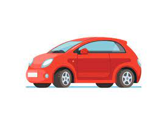

photo by Adobe Stock

## **Why care about statistics?**

Statistics is skill-based!

And like any skill (e.g., playing piano, learning a new language, dribbling a ball), it requires practice, practice, and even more practice.

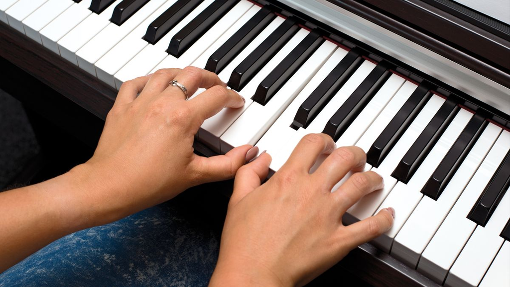

photo by MusicRadar

# Syllabus

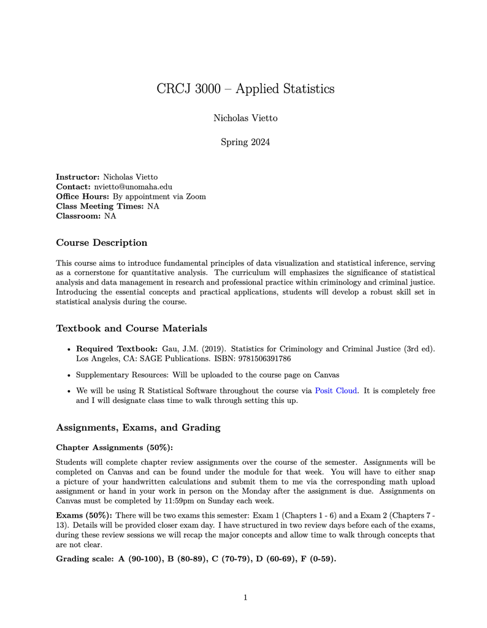

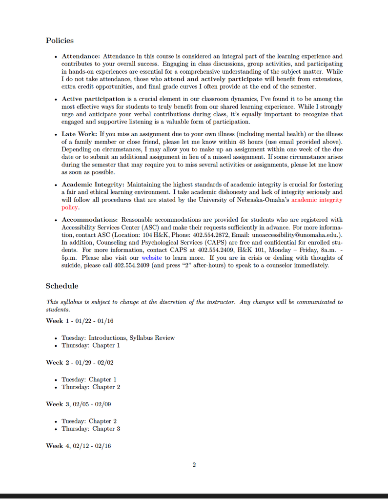

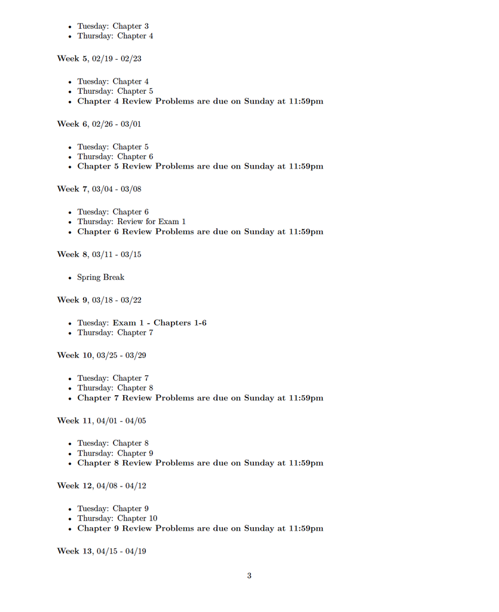

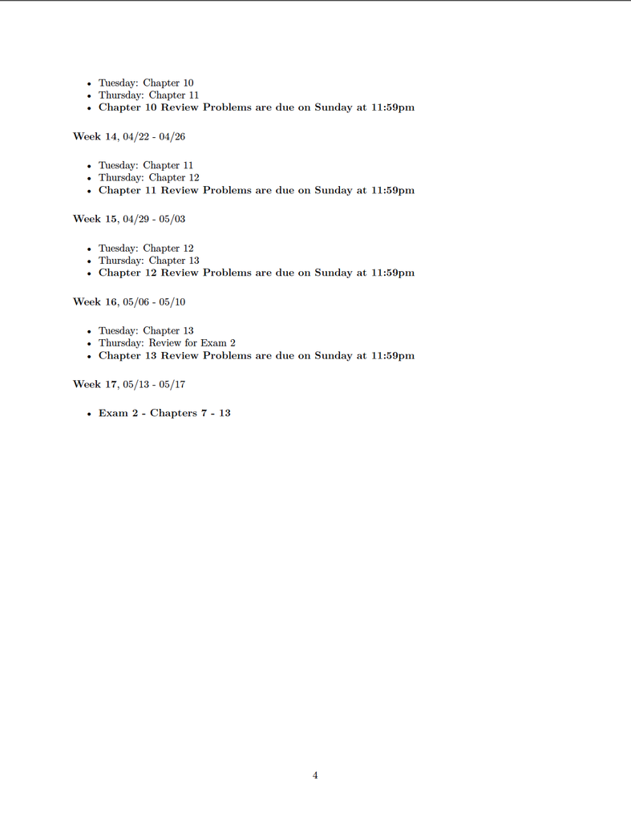

## Class Structure

- Slides will be available on Canvas (Files/Lecture Slides) after we cover each chapter.
  - Everything you *need* to know is **not** in the slides
- Each lecture will be conducted with open discussion and participation is expected.

## My Expectations

- **Read**
- **Show up to class**
  - This material is cumulative (i.e., it snowballs) and missing lectures will impede your understanding of the material
  - If missing class is unavoidable, let me know.
- **Participate**

## Academic Honesty

I encourage you all to work together on assignments, however submitted assignments should be done individually and should be written in your own words.

Exams will be completed in-person, so I will know if you cheat (e.g., ChatGPT) on your homework.

ChatGPT (or any LLM) is a tool that I encourage you to use if you get stuck on something or need clarification **but** copy and pasting from it is plagiarism and I will treat it as such.

## Participation & Climate

- Inclusive environment
  - This class can & should be a place for *active* discussions. This is where learning ‘comes to life.’
- Consider the discussion ‘space’ you take up
  - Allow others to speak.
    - If you find yourself taking up most of the discussion, take a break & give room for others to participate.
  - This space is for all of us.

## Office Hours

- A couple options:
  - Talk to me after class
  - We can set up a time on Zoom

## Technology in the Classroom

- Learning requires *intense* attention.
  - Focusing without distraction, allows your *specific* brain circuits to strengthen which ‘cements’ the skill.
  - If you are distracted or *‘task switching,’* you will have too many circuits firing to promote optimal learning.

# Questions?

# Have a great day!

[figure not shown]

image: giphy